# Variance Estimation: Finite Population Correction, Design Effect, and More

Lecture 9D

PUBHBIO 6250

## Finite Population Correction (FPC)

- In probability sampling (complex surveys):
  - The population (size) is finite
  - Sampling is done without replacement
- Consequence:
  - If the population is small, we get a gain in precision compared to assuming the population is infinite / sampling with replacement
  - Extreme case: Sample **all** of the population ($n=N$) $\rightarrow V(\bar{y}) = 0$
- In fact, in an SRS:
  - Infinite population/sample with replacement: $\displaystyle V(\bar{y}) = \frac{V(y)}{n}$
  - Finite population/sample without replacement: $\displaystyle V(\bar{y}) = \underbrace{\textcolor{#008000}{\left( 1 - \frac{n}{N}\right)}}_{\text{FPC}} \frac{V(y)}{n}$
  - For a fixed $N$, larger $n$ $\rightarrow$ smaller FPC $\rightarrow$ smaller $V(\bar{y})$

## Illustration of FPC

- Population of $N=$ 1,000
- Mean of $y$ = 10.0
- Variance of $y$ = $V(y)$ = 1

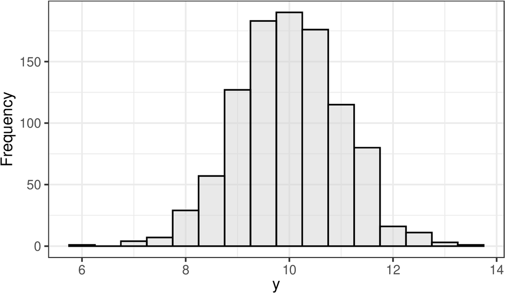

| $n$ | 10 | 50 | 100 | 500 |
| --- | --- | --- | --- | --- |
| FPC = $1-n/N$ | 0.99 | 0.95 | 0.9 | 0.5 |

**Samples of various sizes**

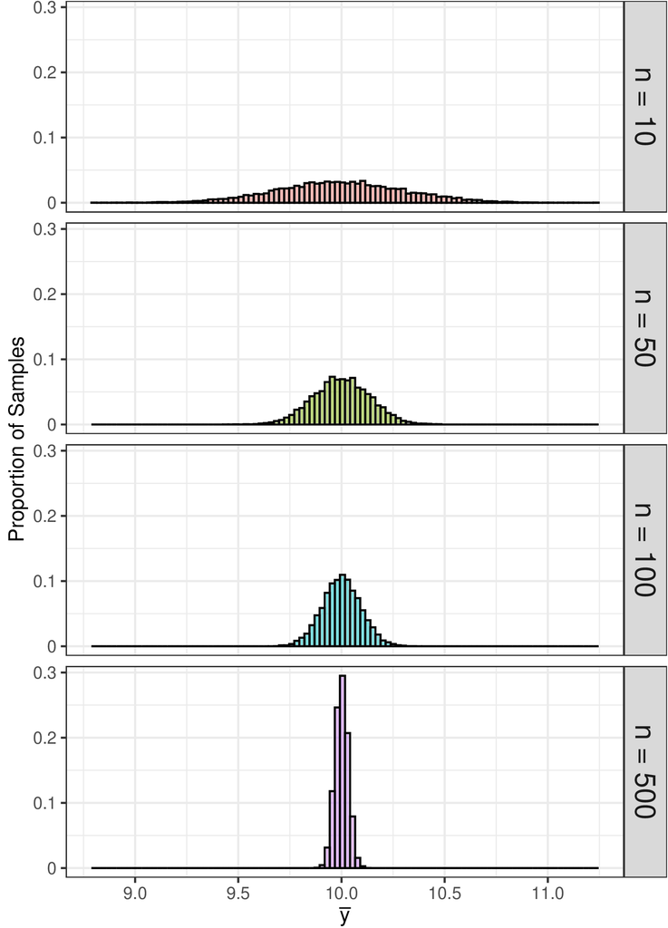

## Example of When We Benefit From the FPC

2022 Ohio Pregnancy Assessment Survey – Stratified design, with SRS taken in each stratum

| **Stratum** | **Population Size** ($N$) | **Sample Size** ($n$) | **FPC** = $\left(1-\frac{n}{N}\right)$ |
| --- | --- | --- | --- |
| 1 | 4,335 | 1,080 | 0.751 |
| 2 | 4,958 | 1,080 | 0.782 |
| 3 | 2,990 | 1,092 | 0.635 |
| 4 | 5,300 | 1,092 | 0.794 |
| 5 | 8,222 | 1,570 | 0.809 |
| 6 | 12,089 | 1,570 | 0.870 |
| 7 | 6,560 | 1,570 | 0.761 |
| 8 | 24,091 | 1,586 | 0.934 |
| 9 | 53,894 | 2,256 | 0.958 |

- Large fraction of some strata sampled $\rightarrow$ FPC matters (FPC $<<1$)
- Consequence of ignoring FPC = variance estimates **too large** (conservative)

## Example of When We Can Ignore the FPC

2023 Ohio Medicaid Disparities Survey – Stratified design, with SRS taken in each stratum

| **Stratum** | **Population Size** ($N$) | **Sample Size** ($n$) | **FPC** = $\left(1-\frac{n}{N}\right)$ |
| --- | --- | --- | --- |
| 1 | 428,999 | 600 | 0.999 |
| 2 | 233,669 | 500 | 0.998 |
| 3 | 276,951 | 500 | 0.998 |
| 4 | 382,733 | 800 | 0.998 |
| 5 | 14,371 | 200 | 0.986 |
| 6 | 27,351 | 100 | 0.996 |
| 7 | 145,904 | 300 | 0.998 |
| 8 | 16,405 | 100 | 0.994 |
| 9 | 43,256 | 100 | 0.998 |

- Tiny fraction sampled in all strata $\rightarrow$ FPC $\approx$ 1
- FPC can be ignored (essentially no variance reduction)

## Design Effect

**Design Effect** = measure of the efficiency of a sampling plan, relative to an SRS

$$\text{DEFF}(\text{plan, statistic}) = \frac{V(\text{estimator from sampling plan})}{V(\text{estimator from SRS with same total sample size})}$$

- DEFF is **statistic-dependent**
  - Different parameters estimated $\rightarrow$ different DEFF (for same sampling design)
- **DEFF $<$ 1** $\rightarrow$ your design is **better** than SRS
- **DEFF $>$ 1** $\rightarrow$ your design is **worse** than SRS
- Certain design features often lead to large/small DEFF:
  - **Stratification** $\rightarrow$ often results in gain in precision $\rightarrow$ **DEFF $<$ 1**
  - **Clustering** $\rightarrow$ often results in loss of precision $\rightarrow$ **DEFF $>$ 1**

## Variance Estimation: Linearization

- The variance of a (weighted) estimator depends on the design:
  - How large is $n$ relative to $N$? (FPC)
  - Is there stratification?
  - Is there clustering?
  - Is sampling (at each stage) by SRS or PPS (or another method)?
- There are **explicit formulae** for (weighted) estimators from various designs
- Broadly speaking, we can (usually) write down an explicit variance formula for a (weighted) estimate of a **total** or a **mean**…
- …and use this to obtain variance estimates for **other quantities that are functions of totals**
- This process is called **(Taylor Series) Linearization** and is the default variance calculation method in most software

## Variance Estimation: Replicate Weights

- Linearization is not the only option for estimating variances of estimates
- Alternate approach: **Resampling Methods**
  - Balanced Repeated Replication (BRR)
  - Jackknife (lots of variations)
  - Bootstrap (lots of variations)
- Resampling methods **re-create the sample**, repeatedly, using the sample data
- A teeny bit of math to illustrate how resampling methods work:
  - Population quantity we want to estimate: $\theta$ (e.g., mean of $y$); point estimate: $\hat{\theta}$
  - Via one of the resampling methods, we create $R$ resampled datasets
  - Variance estimate from resampling method: $\displaystyle \widehat{V}(\hat{\theta}) = \frac{A}{R}\sum_{r=1}^R \left(\hat{\theta}^{(r)} - \widetilde\theta \right)^2$
    - $A$ = scaling constant depending on the method; $\widetilde\theta$ = average of the $R$ estimates $\hat\theta^{(r)}$

## Variance Estimation: Replicate Weights

- Do not create lots of datasets – instead, manipulate sampling weights
- **Replicate weights** are created that capture the variability and allow end users to calculate standard errors **without knowing design information**
- Pros:
  - Can suppress design information (e.g., strata, PSUs) (reduce disclosure risk)
- Cons:
  - Computationally intensive
  - Post-survey adjustments must be done for all sets of weights
  - BRR requires a very specific design: 2 PSUs per stratum
- For **publicly available datasets**, agencies decide to either:
  - Release design information (so you can use linearization)
  - Release masked (“pseudo”) design information (so you can use linearization)
  - Release no design information and give you replicate weights

## Tips for Secondary Data Analysis

- Finite Population Correction (FPC)
  - Most large-scale surveys will have FPC $\approx$ 1 (can be ignored)
  - To account for FPC, need $N$ – documentation will provide if needed
- Design Effect (DEFF)
  - Software will provide estimates of the DEFF for all survey estimates
  - Keep an eye on these to identify potentially unstable estimates (large DEFF)
- Variance Estimation Method
  - Linearization is appropriate most of the time
  - If a survey has replicate weights provided, use them instead
    - Documentation will describe replicate weights and how to use them
    - Example: Current Population Survey (weights: `REPWTP1-REPWTP160`)